# R Markdown Test

Matthew Fritscher

2023-01-27

In times of high inflation, many people may ask the question: what does the central bank do to fight inflation? The Federal Open Markets Committee (FOMC) responds to high inflation by raising the federal funds rate. The federal funds rate, essentially is the interest rate at which banks borrow money from each other. The federal funds rate, therefore, has an effect on all other interest rates in the economy; so if the federal funds rate increases, as do other interest rates. Higher interest rates make it more expensive to borrow money and deincintivizes people from making large purchases. More spending in the economy (and the printing of money) ultimately determines inflation.

Let’s investigate how the past relationship between the federal funds rate and inflation in the past.

## Loading in the dataset

```r
df <- read.csv('index.csv')
summary(df)
```

```
##       Year          Month             Day         Federal.Funds.Target.Rate
##  Min.   :1954   Min.   : 1.000   Min.   : 1.000   Min.   : 1.000
##  1st Qu.:1973   1st Qu.: 4.000   1st Qu.: 1.000   1st Qu.: 3.750
##  Median :1988   Median : 7.000   Median : 1.000   Median : 5.500
##  Mean   :1987   Mean   : 6.598   Mean   : 3.598   Mean   : 5.658
##  3rd Qu.:2001   3rd Qu.:10.000   3rd Qu.: 1.000   3rd Qu.: 7.750
##  Max.   :2017   Max.   :12.000   Max.   :31.000   Max.   :11.500
##                                                   NA's   :442
##  Federal.Funds.Upper.Target Federal.Funds.Lower.Target
##  Min.   :0.2500             Min.   :0.0000
##  1st Qu.:0.2500             1st Qu.:0.0000
##  Median :0.2500             Median :0.0000
##  Mean   :0.3083             Mean   :0.0583
##  3rd Qu.:0.2500             3rd Qu.:0.0000
##  Max.   :1.0000             Max.   :0.7500
##  NA's   :801                NA's   :801
##  Effective.Federal.Funds.Rate Real.GDP..Percent.Change. Unemployment.Rate
##  Min.   : 0.070               Min.   :-10.000           Min.   : 3.400
##  1st Qu.: 2.428               1st Qu.:  1.400           1st Qu.: 4.900
##  Median : 4.700               Median :  3.100           Median : 5.700
##  Mean   : 4.911               Mean   :  3.138           Mean   : 5.979
##  3rd Qu.: 6.580               3rd Qu.:  4.875           3rd Qu.: 7.000
##  Max.   :19.100               Max.   : 16.500           Max.   :10.800
##  NA's   :152                  NA's   :654               NA's   :152
##  Inflation.Rate
##  Min.   : 0.600
##  1st Qu.: 2.000
##  Median : 2.800
##  Mean   : 3.733
##  3rd Qu.: 4.700
##  Max.   :13.600
##  NA's   :194
```

## Data Wrangling

Here we can see there are some columns that have a lot of missing values

```r
# This function replaces any missing values in the input columns with the average of the surrounding values
# while ignoring any missing values in the average calculation.

averager <- function(columnName){
  emptyVector = c()
  for (i in (columnName)){
    if (is.na(i)){
      i <- 0
      if (i != 0){
        emptyVector <- append(emptyVector, i)
      }
      else{
        i <- mean(columnName[i-12], columnName[i+12], na.rm=TRUE)
        emptyVector <- append(emptyVector, i)
      }
    }

    else{
      emptyVector <- append(emptyVector, i)
    }
  }
  return(emptyVector)
}
```

```r
# # Apply the averager function to the relevant columns
#
# looper <- function(columnsVector, startIndex, endIndex){
#   df_clean <- data.frame(matrix(ncol = length(columnsVector), nrow = endIndex - startIndex))
#   colnames(df_clean) <- columnsVector
#
#
#   for (column in columnsVector){
#     res <- averager(df$column[startIndex:endIndex])
#     df_clean <- rep(res, nrow(df_clean))
#   }
#   return(df_clean)
# }
```

```r
# # Setting up the input vector.
#
# colsVec <- colnames(df)
#
# print(length(colsVec))
#
# # print(looper(colsVec, 43, 904))
```

Applying the `averager` function to the appropriate columns

```r
library('stringr')

inflationRate <- averager(df$Inflation.Rate[43:904])

unemploymentRate <- averager(df$Unemployment.Rate[43:904])

effective_fed <- averager(df$Effective.Federal.Funds.Rate[43:904])

dateCol <- str_c(df$Year[43:904],'-', df$Month[43:904],'-', + df$Day[43:904])

Year <- df$Year[43:904]

new_df <- data.frame(
  Inflation.Rate = inflationRate,
  Unemployment.Rate = unemploymentRate,
  Effective.Federal.Funds.Rate = effective_fed,
  Date = dateCol,
  Year = Year
)
```

Now that the desired data frame is cleaned; let’s look at some visualizations.

## Data Visualizations

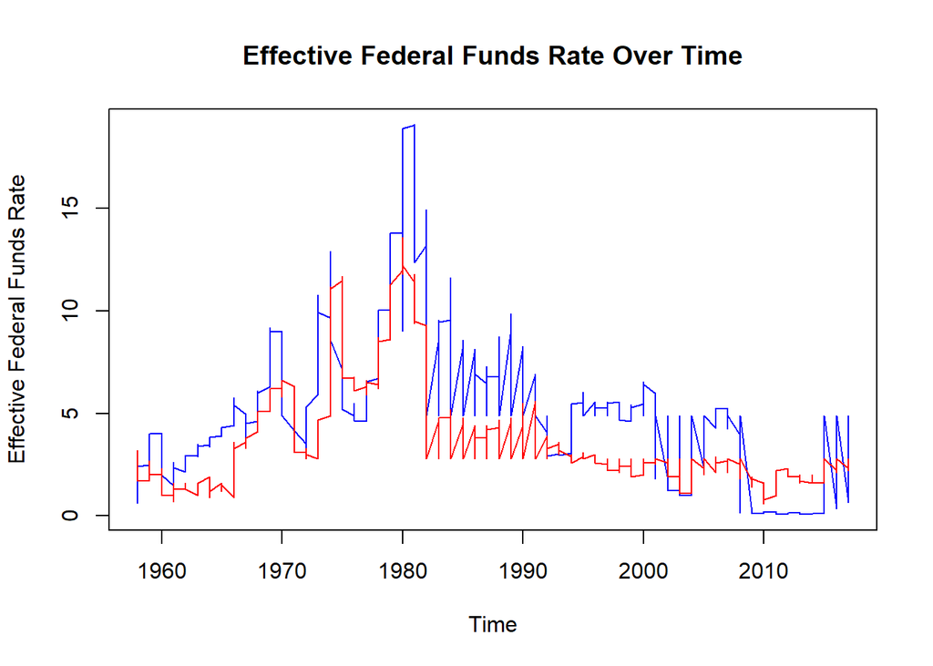

```r
plot(y=new_df$Effective.Federal.Funds.Rate, x=new_df$Year, main="Effective Federal Funds Rate Over Time", ylab="Effective Federal Funds Rate", xlab="Time", col="white")
lines(y=new_df$Effective.Federal.Funds.Rate, x=new_df$Year, col="blue")

lines(y=new_df$Inflation.Rate, x=new_df$Year, col="red")
```

```r
cor(df$Effective.Federal.Funds.Rate, df$Inflation.Rate, use="complete.obs")
```

```
## [1] 0.7843761
```

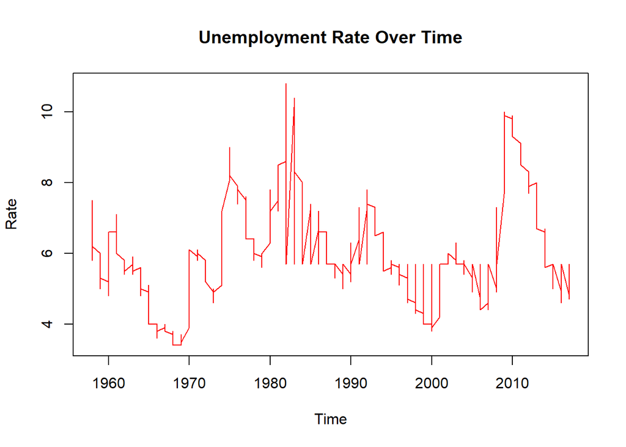

```r
plot(y=new_df$Unemployment.Rate, x=new_df$Year, main="Unemployment Rate Over Time", ylab="Rate", xlab="Time", col="white")


lines(y=new_df$Unemployment.Rate, x=new_df$Year, col="red")
```